# **From Jobstreet to Insights: Mapping Malaysia's Job Market**

[figure not shown]

# **Objective**

This project aims to dive deep into Malaysia’s employment landscape by analyzing job listings data from Jobstreet, one of the country’s most popular job platforms. The analysis explores key insights using real job data that was scraped privately from **Jobstreet** website and made it available on [Kaggle](https://www.kaggle.com/datasets/azraimohamad/jobstreet-all-job-dataset/data). The core objective is to uncover significant patterns that could benefit job seekers, HR professionals, or policymakers with a deeper understanding of jobs availability across industries, companies and regions in Malaysia.

Beyond data analysis, this project also demonstrates data management skills by leveraging a big data platform called **Apache Hive**. Hive functions as a data warehouse, designed for storing and analyzing large datasets for reporting. In this project, our data resides in Hive, and we employ Structured Query Language **(SQL)** to query it. This extracted data is then channeled into **Python** for data manipulation, cleaning, and visualization, providing actionable insights.

# **Problem Statements**

To guide our analysis of the Malaysian job market, we've established the following key questions we aim to answer:

**1. Which companies are actively hiring?**

- This part of the analysis highlights the top companies with the most job postings. We want to explore why some companies contributes high job listings in Jobstreet.

**2. What are the top job locations for each category?**

- By analyzing locations per job category, we can identify areas where specific job markets are concentrated and understand where opportunities are expanding.

**3. What are the most prevalent job categories listed on Jobstreet Malaysia?**

- Understanding which job categories dominates the listings gives an overview of industry demand in Malaysia. This insight can help job seekers and SPM leavers to target high-opportunity fields, and enable government and education sectors to align training programs to market needs.

**4. How are job subcategories distributed within major categories?**

- Beyond major categories, this analysis drills down into specific subcategories (e.g., "Financial Accounting and Reporting" or "Account Relationship Management" within the "Accounting" category). This helps identify niche skills and specialized demands within each broader field.

**5. Among part-time job listings, which job sub-category tends to offer part-time roles the most?**

- The analysis uncovers which sectors are more open to flexible work arrangements. This is ideal for people looking for side income, students or part-time employment.

# **Dataset Overview**

The dataset used in this project contains a huge range of job listings from Jobstreet and it includes detailed information such as:

1. **job_id** : Unique identifier for each job listing
2. **job_title** : The title of the job position (e.g., Software Engineer, Accountant)
3. **company** : Name of the company offering the job
4. **descriptions** : Job descriptions
5. **location** City or region in Malaysia where the job is located
6. **category** : Broad job category (e.g. Accounting, Engineering, etc.)
7. **subcategory** : More specific area within the category (e.g., Mechanical Engineering, Software Developer)
8. **role**: Job role or function (e.g., account-executive)
9. **type** : Employment type (e.g., Full-Time, Part-Time etc.)
10. **salary** : Salary information if provided (e.g., RM3,000 - RM5,000)
11. **listingdate** : Date the job was posted/listed on JobStreet

# **Data Pre-processing**

First, we started by uploading the dataset into Hive and defining the delimiters, escape characters, and quote characters. However, we encountered significant issues with CSV parsing, where most of the observations ended up as NULL values.

Upon investigation, we found that the root cause was the descriptions column, which contains multiple paragraphs, newline characters, and a mix of punctuations. The lack of a consistent format in the job descriptions created a parsing nightmare. For example, commas within the descriptions field were misinterpreted as column separators, and newline characters were treated as indicators of a new row.

Here’s a sample of job description:

Job Description Human Resource

- Cover full spectrum of HR duties including recruitment, maintaining personnel files, leave records, payroll information, statutory contribution and deduction (KWSP, SOCSO, EIS, PCB, HRDF), employee benefit and welfare, etc.

- Manage and perform the HR function within the company.

- Ensure job related, procedure and policy compliance with Malaysia Government labor legislation and regulations.

**Fix:** Since our analysis does not involve text-based tasks like sentiment analysis or word cloud generation, we opted for a quick and practical solution: dropping the descriptions column entirely before uploading the cleaned dataset into Hive.

```python
#importing packages

import pandas as pd
import numpy as np
import matplotlib.pyplot as plt
import seaborn as sns
from datetime import datetime as dt
import os
import warnings #to filter warnings
```

```python
#improting data to pre-processinng
rawdata = pd.read_csv('jobstreet_all_job_dataset.csv')
rawdata.head(3)
```

|  | job_id | job_title | company | descriptions | location | category | subcategory | role | type | salary | listingDate |
| --- | --- | --- | --- | --- | --- | --- | --- | --- | --- | --- | --- |
| 0 | 74630583.0 | Procurement Executive (Contract) | Coca-Cola Bottlers (Malaysia) Sdn Bhd | Position Purpose\nManage aspects of procuremen... | Negeri Sembilan | Manufacturing, Transport & Logistics | Purchasing, Procurement & Inventory | procurement-executive | Contract/Temp | NaN | 2024-03-21T05:58:35Z |
| 1 | 74660602.0 | Account Executive/ Assistant | Acoustic & Lighting System Sdn Bhd | We are looking for a Account Executive/ Assist... | Petaling | Accounting | Bookkeeping & Small Practice Accounting | executive-assistant | Full time | RM 2,800 – RM 3,200 per month | 2024-03-22T06:52:57Z |
| 2 | 74655679.0 | Data Analyst - Asset Management, SPX Express | Shopee Mobile Malaysia Sdn Bhd | Performs detailed data analysis on existing sp... | Klang District | Manufacturing, Transport & Logistics | Analysis & Reporting | asset-management-analyst | Full time | NaN | 2024-03-22T04:22:43Z |

```python
rawdata.info()
```

```
<class 'pandas.core.frame.DataFrame'>
RangeIndex: 69024 entries, 0 to 69023
Data columns (total 11 columns):
 #   Column        Non-Null Count  Dtype
---  ------        --------------  -----
 0   job_id        69024 non-null  float64
 1   job_title     69024 non-null  object
 2   company       69024 non-null  object
 3   descriptions  69024 non-null  object
 4   location      69024 non-null  object
 5   category      69024 non-null  object
 6   subcategory   69024 non-null  object
 7   role          66772 non-null  object
 8   type          69024 non-null  object
 9   salary        31594 non-null  object
 10  listingDate   69024 non-null  object
dtypes: float64(1), object(10)
memory usage: 5.8+ MB
```

```python
#transform the data especially, date
rawdata['listingDate'] = pd.to_datetime(rawdata['listingDate'], errors = 'coerce')
rawdata['listingDate'] = rawdata['listingDate'].dt.date #just want to convert into yyyy-dd-mm
```

```python
#to convert job ID into integer
rawdata['job_id'] = rawdata['job_id'].astype(int)

#to drop descriptions
rawdata = rawdata.drop('descriptions', axis = 1)
rawdata.head(3)
```

|  | job_id | job_title | company | location | category | subcategory | role | type | salary | listingDate |
| --- | --- | --- | --- | --- | --- | --- | --- | --- | --- | --- |
| 0 | 74630583 | Procurement Executive (Contract) | Coca-Cola Bottlers (Malaysia) Sdn Bhd | Negeri Sembilan | Manufacturing, Transport & Logistics | Purchasing, Procurement & Inventory | procurement-executive | Contract/Temp | NaN | 2024-03-21 |
| 1 | 74660602 | Account Executive/ Assistant | Acoustic & Lighting System Sdn Bhd | Petaling | Accounting | Bookkeeping & Small Practice Accounting | executive-assistant | Full time | RM 2,800 – RM 3,200 per month | 2024-03-22 |
| 2 | 74655679 | Data Analyst - Asset Management, SPX Express | Shopee Mobile Malaysia Sdn Bhd | Klang District | Manufacturing, Transport & Logistics | Analysis & Reporting | asset-management-analyst | Full time | NaN | 2024-03-22 |

```python
# exporting pre-processed data into csv
#uploading into Hive
rawdata.to_csv('jobstreet.csv', index = False)
```

## **Connecting notebook to Hive**

In this part, we connect with Hive from Jupyter notebook. To ensure a smooth integration, we turn on the Hortonworks SDP, a virtual machine running in Virtual Box to connect with Ambari - a management platform that provides web-based user interfaces and APIs for monitoring, managing, and provisioning Apache Hadoop clusters.

```python
%%capture
!pip install pyhive thrift thrift-sasl pure-sasl impyla
```

```python
from impala.dbapi import connect

conn = connect(host="127.0.0.1",
               port=10000,
               user="maria_dev",
               database = "default",
               auth_mechanism='PLAIN')
cursor = conn.cursor()
```

# **Results and Analysis**

## **1. Which companies are actively hiring?**

```python
query4 = """
SELECT
    company,
    COUNT (*) AS job_count
FROM jobstreet
GROUP BY company
ORDER BY job_count DESC

LIMIT 51
"""
#limit is 51 to exclude private advertiser

tophiringcompany = pd.read_sql(query4, conn)
tophiringcompany.head(10)
# warnings.filterwarnings('ignore', category=UserWarning) #to ignore warning.
```

|  | company | job_count |
| --- | --- | --- |
| 0 | Private Advertiser | 2197 |
| 1 | AGENSI PEKERJAAN JS STAFFING SERVICES SDN BHD | 281 |
| 2 | Agensi Pekerjaan PERSOLKELLY Malaysia Sdn Bhd | 237 |
| 3 | Agensi Pekerjaan Hays (Malaysia) Sdn Bhd | 228 |
| 4 | Michael Page International (Malaysia) Sdn Bhd | 211 |
| 5 | RHB Banking Group | 200 |
| 6 | Intel Technology Sdn. Bhd. | 199 |
| 7 | DKSH Malaysia Sdn Bhd | 189 |
| 8 | PERSOLKELLY Workforce Solutions Malaysia Sdn Bhd | 187 |
| 9 | Sunway Berhad | 166 |

[figure not shown]

```python
#plotting the graph

#need to differentiate between employment agency and other companies.
agency = ["AGENSI PEKERJAAN JS STAFFING SERVICES SDN BHD",
          "Agensi Pekerjaan PERSOLKELLY Malaysia Sdn Bhd",
          "Agensi Pekerjaan Hays (Malaysia) Sdn Bhd",
          "Michael Page International (Malaysia) Sdn Bhd",
          "PERSOLKELLY Workforce Solutions Malaysia Sdn Bhd",
          "Agensi Pekerjaan Achieve Career Consultant (M) Sdn Bhd (JTKSM 579)",
          "Agensi Pekerjaan GMRecruitment Sdn Bhd",
          "Agensi Pekerjaan Randstad Sdn Bhd - Professional" ]

plt.figure(figsize=(12, 16))
subset = tophiringcompany.iloc[2:52].sort_values(by = 'job_count', ascending = True) #to filter out private advertiser
colors = ['grey' if company in agency else 'lightblue' for company in subset['company']] #to define colour if listed as agency
bars = plt.barh(subset['company'], subset['job_count'], color = colors)

plt.title("Top 50 Companies with the Most Job Listings on Jobstreet")
plt.xlabel("Total Jobs Listing")
plt.ylabel("Companies")

plt.show()
```

## **2. What are the top job locations for each category?**

```python
query5 = """

WITH data_grouped AS (
    SELECT
        category,
        location,
        COUNT(*) AS job_count
    FROM jobstreet
    GROUP BY category, location
),

ranked_locations AS (
    SELECT *,
        ROW_NUMBER() OVER (PARTITION BY category ORDER BY job_count DESC) AS rank --to asssign a rank per category
    FROM data_grouped
)
SELECT category, location, job_count
FROM ranked_locations
WHERE rank <= 10
ORDER BY category, job_count DESC
"""
#limit is 51 to exclude private advertiser

joblocation = pd.read_sql(query5, conn)
```

We only interested in certain categories to see locations for that categories. So we then filtered data based on the selected categories.

```python
selected_cat = ['Engineering',
                'Information & Communication Technology',
                'Accounting',
                'Manufacturing, Transport & Logistics',
                'Construction',
                'Real Estate & Property',
                'Hospitality & Tourism',
                'Healthcare & Medical',
                'Mining, Resources & Energy']
data_filtered = joblocation[joblocation['category'].isin(selected_cat)]
```

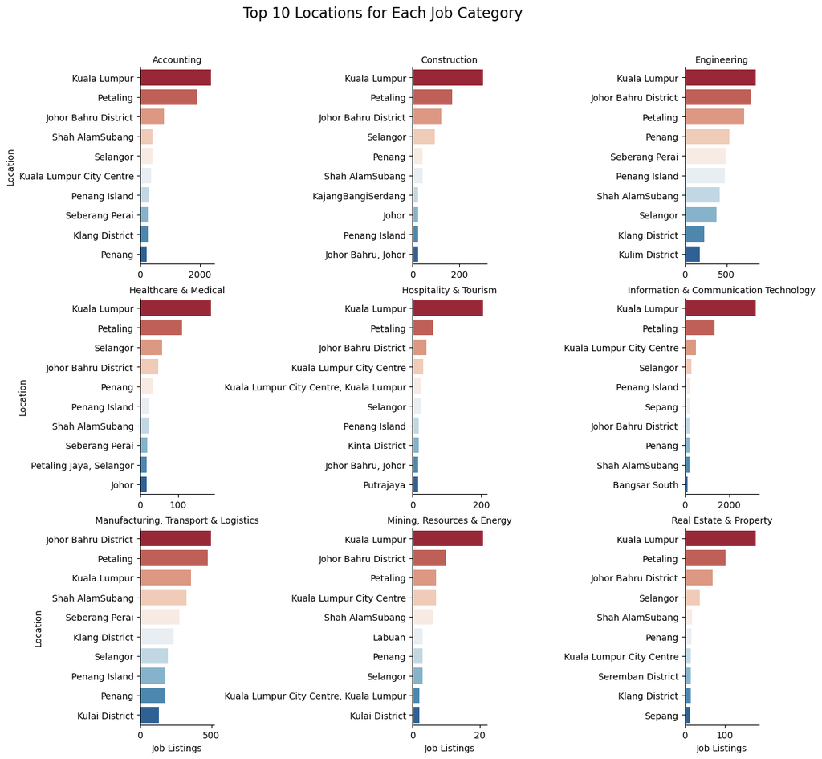

```python
##plot using FacetGrid
g = sns.FacetGrid(
    data_filtered,
    col='category',
    col_wrap=3,
    height=4,
    sharex=False,
    sharey=False
)

g.map_dataframe(
    sns.barplot,
    x='job_count',
    y='location',
    palette='RdBu'
)

g.set_axis_labels("Job Listings", "Location")
g.set_titles(col_template="{col_name}")
g.fig.subplots_adjust(top=0.9)
g.fig.suptitle("Top 10 Locations for Each Job Category", fontsize=16)
# plt.tight_layout()
plt.show()
warnings.filterwarnings('ignore', category=FutureWarning) #to ignore warning.
```

### Explanation

We then next want to explore the location for each job category. Here, we are interested to dive deep into job locations in 9 categories only.

- Overall, **Kuala Lumpur** stands out as Malaysia's primary job hub due to its high concentration of diverse industries. Most job categories show a dense presence here.
- However, there is a notable exception. **Manufacturing, Transport, and Logistics** roles are more concentrated in **Johor Bahru**.This make sense given Johor's close proximity to Singapore, providing direct access to Singapore's port and major global trade routes, making it an ideal center for logistics operations. For job seekers in this field, Johor Bahru is a key location.
- When comparing between states, **Kuala Lumpur** leads in job opportunities, followed by **Johor**, and then **Penang**.

Interestingly, within the **Engineering** category, the distribution of job listings across different states is more balanced. This suggests that engineering skills are broadly in demand across Malaysia, regardless of location. A similar pattern is seen in the **Manufacturing, Transportation and Logistics** sectors.

- In contrast, we can observe a significant disparity in job listings for other categories, with Kuala Lumpur often having a much higher concentration. This suggests an imbalance in job infrastructure and perhaps an over-centralization of certain industries. This high concentration in major cities like KL can lead to social impacts, such as high population density. To foster more balanced growth and reduce the need for young talent to migrate to main cities, states might consider investing in and developing their local talent in fields like IT, Hospitality, and Tourism. This could help create more equitable job opportunities across Malaysia.

## **3. What are the most prevalent job categories listed on Jobstreet Malaysia?**

```python
query = """
SELECT
    category,
    COUNT(category) AS job_count
FROM
    jobstreet
GROUP BY
    category
ORDER BY
    job_count DESC
"""
jobstreet1 = pd.read_sql(query, conn)
print(jobstreet1.head(5))

# warnings.filterwarnings('ignore', category=UserWarning) #to ignore warning.
```

```
                                 category  job_count
0                              Accounting      11154
1                             Engineering       8750
2  Information & Communication Technology       8267
3         Administration & Office Support       6848
4                                   Sales       5641
```

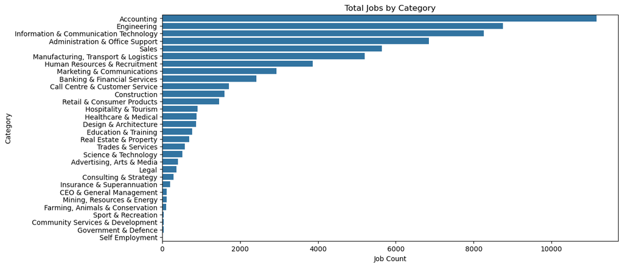

```python
#plotting the bar

plt.figure(figsize=(12,6))
sns.barplot(data=jobstreet1, x='job_count', y='category')
plt.title("Total Jobs by Category")
plt.xlabel("Job Count")
plt.ylabel("Category")
plt.show()
```

#### Explanation

- From the plot, we can see that the top job categories are Accounting, Engineering, and Information & Communication Technology (IT). This indicates that, despite advancements in technology and the common belief that many professions will be replaced by artificial intelligence (AI), accounting remains a highly in-demand field. Accountants are still needed for their expertise in financial advice, analysis, and interpretation.
- Although engineering jobs in Malaysia are often underpaid especially for junior engineers, it remains one of the most sought-after careers in market as engineers plays a critical role in nation's development due to their problem-solving and innovation skills. Country's engineer-to-popukation ratio is low at 1:170, which is significantly below than the average ratio in developed nations. Inadequate salaries for junior engineers partly discourages students or fresh graduates from entering the engineering field. YB Fadillah Yusof, the deputy prime minister, has called on educational institutions and industry players to collaborate with the government to attract more people to choose engineering field as their career. [The Star](https://www.freemalaysiatoday.com/category/nation/2024/09/19/improve-engineer-salaries-to-attract-more-students-to-stem-says-fadillah)
- Jobs in IT also remain in high demand, as businesses increasingly rely on technology expertise to streamline operations and gain a competitive edge.

## **4. How are job subcategories distributed within major categories?**

```python
query2 = """
SELECT
    category,
    subcategory
FROM
    jobstreet
"""

jobstreet2 = pd.read_sql(query2, conn)
jobstreet2.head(5)
```

|  | category | subcategory |
| --- | --- | --- |
| 0 | Manufacturing, Transport & Logistics | Purchasing, Procurement & Inventory |
| 1 | Accounting | Bookkeeping & Small Practice Accounting |
| 2 | Manufacturing, Transport & Logistics | Analysis & Reporting |
| 3 | Engineering | ElectricalElectronic Engineering |
| 4 | Manufacturing, Transport & Logistics | Purchasing, Procurement & Inventory |

```python
top12category = jobstreet1['category'].head(12).tolist()
```

```python
subcategory = jobstreet2[jobstreet2['category'].isin(top12category)]
subcategory.head(10)
```

|  | category | subcategory |
| --- | --- | --- |
| 0 | Manufacturing, Transport & Logistics | Purchasing, Procurement & Inventory |
| 1 | Accounting | Bookkeeping & Small Practice Accounting |
| 2 | Manufacturing, Transport & Logistics | Analysis & Reporting |
| 3 | Engineering | ElectricalElectronic Engineering |
| 4 | Manufacturing, Transport & Logistics | Purchasing, Procurement & Inventory |
| 5 | Accounting | Financial Accounting & Reporting |
| 6 | Accounting | Financial Accounting & Reporting |
| 7 | Engineering | Project Engineering |
| 8 | Accounting | Accounts Payable |
| 9 | Administration & Office Support | Administrative Assistants |

```python
sub_grouped = subcategory.groupby(['category','subcategory']).size().reset_index(name = 'job_count')
sub_sorted = sub_grouped.sort_values(['category','job_count'], ascending = [True,False]) # sort by jobcount, so we can have top subcategory
sub_top3 = sub_sorted.groupby('category').head(3) #group by category and just pick top 3 only
sub_top3['category'] = pd.Categorical(sub_top3['category'], categories=top12category, ordered=True)

warnings.filterwarnings('ignore') #to ignore warning.
```

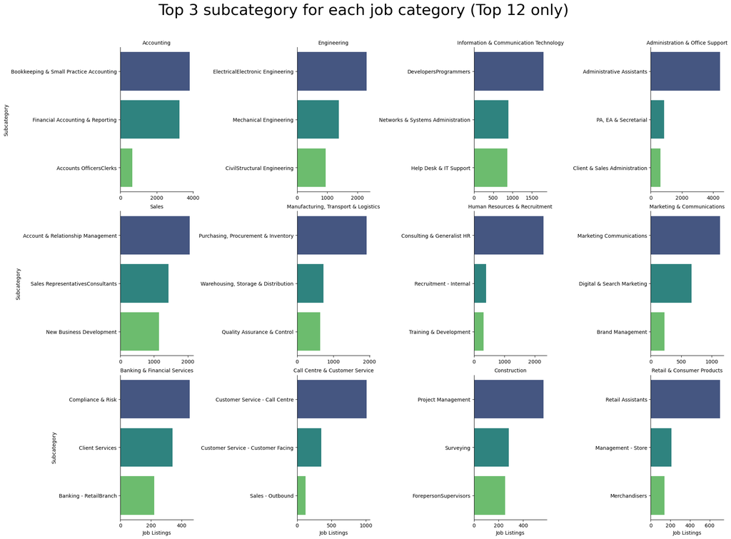

```python
#plotting the graph

plotsub= sns.FacetGrid(sub_top3,
    col='category',
    col_wrap=4,
    height=5,
    sharex=False,
    sharey=False
)

plotsub.map_dataframe(
    sns.barplot,
    x='job_count',
    y='subcategory',
    palette='viridis'
)

plotsub.set_axis_labels("Job Listings", "Subcategory")
plotsub.set_titles(col_template="{col_name}")
plotsub.fig.subplots_adjust(top=0.9)
plotsub.fig.suptitle("Top 3 subcategory for each job category (Top 12 only)", fontsize=30)
# plt.tight_layout()
plt.show()
warnings.filterwarnings('ignore', category=FutureWarning) #to ignore warning.
```

#### Explanation

After getting a broader view of the job market, we decided to take a closer look—drilling down into the subcategories to uncover the top three most sought-after roles within each field. Our focus was on the top 12 job categories listed on JobStreet. This level of detail helps us understand not just which field are in demand, but also offers more targeted insights into the kinds of roles companies are actively hiring for.

- Under the **Accounting** category, we can observe that there is a sustained demand for traditional finance roles like 'Bookkeeping and Small Practice Accounting'. These roles are especially prevalent among small to medium-sized enterprises, which rely on solid accounting foundations for their daily operations.
- In **Engineering** field, Electronic Engineering, Mechanical Engineering, and Civil & Structural Engineering are the most prominent roles. This reflect Malaysia rely heavily on core engineering fields, which is critical for country's urban development and infrastructure.
- When we turn our attention to the **Banking and Financial Services** category, the standout subcategories are *Compliance and Risk Management*. The trend reflects that, with growing foreign investment into Asia, there is a rise in complex financial crimes like money laundering, terrorist financing, cybercrime and fraud. In responce, government regulators (e.g. BNM) are enforcing stricter compliance standards to help financial insititutions maintain public trust, which in turn results in increasing regulatory activities. This could be one of the driving factors of demand in compliance and risk management professions. [Source](https://www.hays.com.my/-my-banking-and-financial-services-compliance-trends)
- Furthermore, the data also highlights a strong reliance on operational and support functions. Positions like *Administrative Assistant, Retail Assistant, Network Administrator, and Customer Service Representative* consistently rank among the most listed jobs. These roles are essential for businesses to function efficiently and maintain customer satisfaction.

## **5. Among part-time job listings, which job sub-category tends to offer part-time roles the most ?**

```python
query3 = """
SELECT
    subcategory,
    category,
    type
FROM jobstreet
"""
jobcat= pd.read_sql(query3, conn)
jobcat['type'].unique() #the values in type column is not standardized.
```

```
array(['ContractTemp', 'Full time', 'CasualVacation', 'Part time',
       "['Full time']", "['ContractTemp']", "['Part time']",
       "['ContractTemp', 'Full time']", "['CasualVacation']",
       "['Full time', 'Part time']",
       "['ContractTemp', 'Full time', 'Part time']"], dtype=object)
```

```python
#standardize the value
jobcat['type'].replace({
    "['ContractTemp']" : "Temporary Contract",
    "ContractTemp" : "Temporary Contract",
    "['Full time']" : "Full Time",
    "Full time": "Full Time",
    "['CasualVacation']": "Casual Vacation",
    "CasualVacation": "Casual Vacation",
    "['Part time']": "Part Time",
    "Part time": "Part Time",
    "['ContractTemp', 'Full time', 'Part time']": "Temporary Contract/Full Time/Part Time",
    "['ContractTemp', 'Full time']": "Temporary Contract/Full Time",
    "['Full time', 'Part time']" : "Full Time/Part Time"
    }, inplace = True)
```

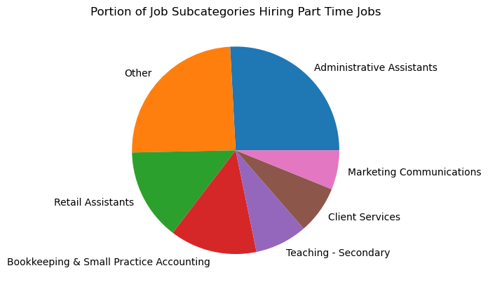

```python
#filter
parttime = jobcat[jobcat['type'].isin(["Part Time"])]
parttime.count = parttime['subcategory'].value_counts().reset_index()
parttime.count.columns = ['subcategory','count']

#plotting
parttime.df = parttime.count.head(7)
plt.pie(parttime.df['count'], labels = parttime.df['subcategory'], shadow = False)
plt.title("Portion of Job Subcategories Hiring Part Time Jobs")
plt.show()
```

#### Explanation

We want to futher explore which sectors are more open to flexible work arrangements, particulartly part-time roles. We filtered the data to include only top 7 subcategories.

# **Conclusion**

The job listings on JobStreet provide a reflection of Malaysia's job infrastructure and can help various stakeholders—such as job seekers, HR professionals, government bodies, and industries—make better-informed decisions. Here’s a summary of the insights gained from the analysis:

Lastly, while this analysis is based solely on data scraped from JobStreet, it still offers a valuable snapshot of Malaysia’s job market infrastructure. For future analysis, we can provide more comprehensive insights when analyse data from platforms like LinkedIn, MyFutureJobs and Maukerja. Still, JobStreet alone gives a good overview of the current job infrastructure across the country.

The analysis is prepared by: Siti Hajar Ibrahim (UKM, May 2025)